# Veen et al. Leaflitter decomposition

```r
library(readxl)
library(tidyverse)
library(ropls)
library(chemhelper)
library(here)
```

[output not shown]

[output cut: 314 more lines]

# Data description

from README.docx

Column: Explanation

- ID: identification number for each individual sample
- transectID: identification number for each transect
- transecttype: type of successional gradient
  - ex-arable: secondary successional gradient on ex-arable fields
  - dunes: primary successional gradient on coastal dunes
  - driftsands: primary successional gradients on drift sands
- site: name of the site where soil and litter were collected
- soilsource: successional stage from which the soil was sourced
  1. early-successional stage
  2. mid-successional stage
  3. late-successional stage
- littersource: successional stage from which the litter was sourced
  1. early-successional stage
  2. mid-successional stage
  3. late-successional stage
- sterilization: litter sterilization treatment - no = litter was not sterilized - yes = litter was sterilized
- mass4: Mass loss after 4 months (%)
- mass12: Mass loss after 12 months (%)

Column: Explanation

- transectID: identification number for each transect
- transecttype: type of successional gradient
  - ex-arable: secondary successional gradient on ex-arable fields
  - dunes: primary successional gradient on coastal dunes
  - driftsands: primary successional gradients on drift sands
- succstage: successional stage from which litter and soil were sourced
  1. early-successional stage
  2. mid-successional stage
  3. late-successional stage
- soilmoist: soil moisture content (%)
- SOM: soil organic matter content (%)
- soilNO3: soil nitrate concentration (µg g-1)
- soilNH4: soil ammonium concentration (µg g-1)
- soilC: soil carbon content (%)
- soilN: soil nitrogen content (%)
- soilP: soil phosphorous content (%)
- litterC: litter carbon content (%)
- litterN: litter nitrogen content (%)
- litterP: litter phosphorous content (%)
- pH: soil pH
- lignin litter lignin content (%)

**Note:** Above, I edited column names so everything soil related had a leading “soil” and everythign litter related has a leading “litter”

```r
soil <- veen.env %>%
  select_at(vars(transectID, succstage, starts_with("soil"))) %>%
  rename(soilsource = succstage)
litter <- veen.env %>%
  select_at(vars(transectID, succstage, starts_with("litter"))) %>%
  rename(littersource = succstage)
veen <- left_join(left_join(veen.mass,soil), litter)
```

I really need to read the paper to get what’s going on here I guess

I could ask, for example, regardless of home field advantage (ignore soilsource and littersource), what soil and litter properties best predict decomposition (mass12)? Probably would want to only use non-sterilized litter?? Could include it to see if it comes out as important variable.

```
PLS
144 samples x 12 variables and 1 response
standard scaling of predictors and response(s)
```

|  | R2X(cum) | R2Y(cum) | Q2(cum) | RMSEE | pre | ort | pR2Y | pQ2 |
| --- | --- | --- | --- | --- | --- | --- | --- | --- |
| Total | 0.186 | 0.377 | 0.271 | 15 | 1 | 0 | 0.05 | 0.05 |

```
Single component model: only 'overview' and 'permutation' (in case of single response (O)PLS(-DA)) plots available
```

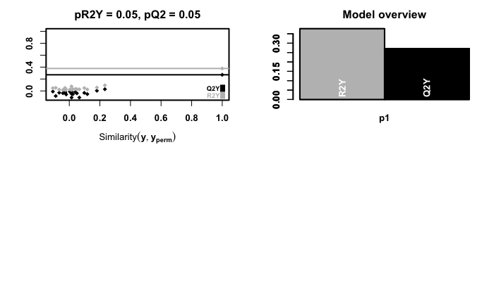

```r
plsr <- opls(select(plsdata, -mass12), plsdata$mass12)
```